# Synchrony Calculation

# Overview

This is the third page of a three-page workflow examining **moment-to-moment dyadic dynamics in baseline couple interaction warmth**. It uses the positive- and negative-discussion long-format trajectories created on the Processing & Visualization page from the CARMA data documented on the Import & Reliability page.

For each couple and discussion type, the analysis estimates whether changes in one partner’s warmth are related to changes in the other partner’s warmth at the same moment or a few seconds later.

The analysis proceeds in three steps:

1. **Remove each person’s own time-series pattern (pre-whitening).** Warmth ratings from one second are naturally related to ratings from the seconds immediately before and after. An ARIMA model is fit separately to mom’s and partner’s warmth series to account for this within-person autocorrelation. The remaining residuals represent moment-to-moment changes in warmth that are not explained by each person’s own prior pattern.
2. **Test synchrony across time lags (cross-correlation).** A cross-correlation function (CCF) compares mom’s and partner’s residualized warmth at the same second and across different time lags. Lag 0 represents concurrent synchrony, while positive and negative lags indicate whether changes in one partner tend to precede changes in the other.
3. **Identify correlations stronger than expected by chance**. The residual series are independently reshuffled many times to create a bootstrap null distribution representing the correlations expected if the two partners’ moment-to-moment changes were unrelated. Observed correlations that exceed these chance-based bounds are identified as significant.

The resulting lag profile is summarized using **concurrent synchrony, maximum synchrony, strongest non-zero-lag synchrony, leader/follower direction, and the time lag at which significant synchrony first appears.**

A positive lag means partner warmth at the current second is associated with mom warmth at a later second, so **partner leads and mom follows**. A negative lag means **mom leads and partner follows**. This direction follows the call `ccf(mom, partner)` and is used consistently throughout the page.

Colors use the Tol muted palette for consistent, colorblind-friendly encoding:

- mom leads / negative lag is blue (`#88CCEE`)
- partner leads / positive lag is rose (`#CC6677`)
- concurrent is green (`#117733`)
- significant is rose against neutral gray,
- and direction-neutral trend lines/ribbons use indigo (`#332288`).

**Workflow**

**1. Import & Reliability** → **2. Processing & Visualization** → **3. Synchrony Calculation**

Import & Reliability · Processing & Visualization · Synchrony Calculation

The positive and negative sections mirror one another, so repeated methodological explanation is abbreviated in the negative section.

**Load Packages**

```r
# Load packages used for data handling, time-series modeling, visualization, and formatted summaries
library(here)
library(nlme)
library(tidyverse)
library(ggplot2)
library(lavaan)
library(semTools)
library(jtools)
library(haven)
library(modsem)
library(forecast)
library(gt)
library(purrr)
```

Long-format positive- and negative-valence baseline warmth data, produced by the Baseline Synchrony Processing pipeline, are read in from where that processed data already lives.

# Positive Interaction

This section calculates synchrony for positive warmth: how closely mom’s and partner’s warm, affectionate behavior track each other, and which partner’s warmth tends to lead the other’s during positive moments of the interaction.

## Synchrony Calculation

The function below does the full per-couple synchrony calculation in three steps.

1. First, it pre-whitens each partner’s warmth series with `auto.arima()` so the cross-correlation reflects genuine coupling between partners rather than each person’s own autocorrelation over time.
2. Second, it computes the observed cross-correlation function between mom’s and partner’s residuals across a range of lags.
3. Third, it builds a bootstrap null distribution by independently reshuffling each partner’s residuals, then flags any lag where the observed correlation falls outside the resulting 95% interval as significant.

`ccf(mom, partner)` at lag *k* estimates the correlation between mom’s residual at time *t + k* and partner’s residual at time *t*.

- A positive *k* means mom’s future value resembles partner’s current value, so partner is leading.
- A negative *k* means mom’s earlier value resembles partner’s current value, so mom is leading.

```r
# Function to compute time-lagged cross-correlation synchrony between dyad members
compute_blpwh_sync <- function(df, lag = 20, n_boot = 1000) {

  # Remove rows with missing data for both mom and partner variables
  df <- df %>% filter(!is.na(blmpwh), !is.na(blfpwh))

  # Check if there's enough data to compute lagged correlations
  if (nrow(df) < lag + 1) return(
    tibble(lag = NA, acf = NA, lower_ci = NA, upper_ci = NA, significant = NA))

  # ── Step 1: Pre-Whiten Each Partner Series ──────────────────────────────
  # Fit models to each person's time series to account for individual patterns
  fit_mom <- tryCatch(auto.arima(df$blmpwh), error = function(e) NULL)
  fit_partner <- tryCatch(auto.arima(df$blfpwh), error = function(e) NULL)

  # If either model fails, return NA results
  if (is.null(fit_mom) || is.null(fit_partner)) return(
    tibble(lag = NA, acf = NA, lower_ci = NA, upper_ci = NA, significant = NA))

  # Extract residuals (pre-whitened series) - these represent deviations from                                                     each person's own temporal pattern
  res_mom <- residuals(fit_mom)
  res_partner <- residuals(fit_partner)

  # Combine residuals and remove any remaining missing values
  residuals_df <- tibble(res_mom, res_partner) %>% drop_na()
  if (nrow(residuals_df) < lag + 1) return(
    tibble(lag = NA, acf = NA, lower_ci = NA, upper_ci = NA, significant = NA))

  # ── Step 2: Compute Observed Cross-Correlation ──────────────────────────
  # Ccf(mom, partner)[k] estimates cor(mom[t+k], partner[t])
  # Negative lags:
  # Mom's earlier value resembles partner's current value -> mom leads partner
  # Positive lags:
  # Mom's future value resembles partner's current value -> partner leads mom
  ccf_result <- ccf(
    residuals_df$res_mom, residuals_df$res_partner, lag.max = lag, plot = FALSE)
  observed_acf <- ccf_result$acf  # Cross-correlation values at each lag
  lags <- ccf_result$lag  # Lag values (e.g., -20 to +20)

  # ── Step 3: Bootstrap the Null Distribution ─────────────────────────────
  # Create matrix to store bootstrap results
  boot_corrs <- matrix(NA, nrow = n_boot, ncol = length(lags))
  n <- nrow(residuals_df)

  # Generate null distribution by randomly shuffling residuals
  # Breaks temporal coupling
  for (i in 1:n_boot) {
    # Resample mom's residuals
    x_boot <- sample(residuals_df$res_mom, n, replace = TRUE)
    # Resample partner's residuals
    y_boot <- sample(residuals_df$res_partner, n, replace = TRUE)
    # Compute CCF on shuffled data
    boot_ccf <- ccf(x_boot, y_boot, lag.max = lag, plot = FALSE)
    # Store correlation values
    boot_corrs[i, ] <- boot_ccf$acf
  }

  # Calculate 95% confidence intervals from bootstrap distribution
  lower_ci <- apply(boot_corrs, 2, quantile, probs = 0.025, na.rm = TRUE)
  upper_ci <- apply(boot_corrs, 2, quantile, probs = 0.975, na.rm = TRUE)

  # Determine significance: observed correlation falls outside 95% CI
  significant <- (observed_acf < lower_ci) | (observed_acf > upper_ci)

  # Return tibble with lag values, correlations, CIs, and significance
  tibble(
    lag = as.numeric(lags),
    acf = as.numeric(observed_acf),
    lower_ci = lower_ci,
    upper_ci = upper_ci,
    significant = significant
  )
}
```

The function above runs once per couple. The chunk below nests the long-format data by couple ID, applies the function to each couple’s data in turn, and unnests the results back into one row per couple per lag.

```r
# Nest data by couple ID (creates list-column with each dyad's time series)
blpwh_sync_id <- BL_WH_Long %>%
  group_by(ID) %>%
  nest()

# Apply the synchrony function to each couple's data
blpwh_sync_id <- blpwh_sync_id %>%
  mutate(blpwh_sync_ccf = map(data, compute_blpwh_sync))

# Unnest results to get one row per couple per lag value
blpwh_sync_results <- unnest(blpwh_sync_id, blpwh_sync_ccf)

blpwh_sync_results$lag <- as.numeric(blpwh_sync_results$lag)
```

## Max Synchrony

For each couple, this pulls out the single lag with the strongest absolute correlation across the full range of lags (including lag zero), regardless of direction. This is the point of tightest overall coupling between mom’s and partner’s positive warmth.

```r
# Extract max synchrony for each couple
blpwh_sync_max <- blpwh_sync_results %>%
  group_by(ID) %>%
  # Find the row with maximum absolute correlation for each couple
  slice_max(abs(acf), n = 1, with_ties = FALSE) %>%
  select(ID,
         max_lag = lag,  # Lag at which max occurs
         max_sync = acf,  # Correlation value (with sign)
         max_abs_sync = acf,  # Will convert to absolute
         lower_ci,
         upper_ci,
         significant) %>%
  mutate(max_abs_sync = abs(max_sync)) %>%  # Add absolute value column
  ungroup()

knitr::kable(anonymize_table_ids(head(blpwh_sync_max, 10)), digits = 3,
             caption =
               "Maximum Synchrony, Positive Interaction (Randomized Couples, Fake IDs)")
```

Maximum Synchrony, Positive Interaction (Randomized Couples, Fake IDs)

| ID | max_lag | max_sync | max_abs_sync | lower_ci | upper_ci | significant |
| --- | --- | --- | --- | --- | --- | --- |
| 6553 | -14 | 0.080 | 0.080 | -0.086 | 0.080 | TRUE |
| 9566 | 0 | 0.143 | 0.143 | -0.081 | 0.085 | TRUE |
| 5477 | -4 | -0.092 | 0.092 | -0.083 | 0.087 | TRUE |
| 5590 | 12 | 0.115 | 0.115 | -0.081 | 0.082 | TRUE |
| 8523 | -12 | 0.142 | 0.142 | -0.078 | 0.081 | TRUE |
| 8079 | 0 | 0.122 | 0.122 | -0.078 | 0.080 | TRUE |
| 7941 | -1 | 0.158 | 0.158 | -0.084 | 0.082 | TRUE |
| 1039 | 9 | -0.115 | 0.115 | -0.081 | 0.075 | TRUE |
| 1176 | -14 | -0.135 | 0.135 | -0.078 | 0.088 | TRUE |
| 4593 | 11 | 0.130 | 0.130 | -0.072 | 0.074 | TRUE |

### Max Synchrony Interpretation

This translates the raw max-synchrony lag into a plain-language leader label, using the direction established above (negative lag, mom leads; positive lag, partner leads), and adds a rough strength category based on the size of the correlation.

```r
# Add interpretation columns
blpwh_sync_max_interpret <- blpwh_sync_max %>%
  mutate(
    # Who leads? Negative lag = mom leads, positive lag = partner leads
    leader = case_when(
      max_lag < 0 ~ "Mom leads",
      max_lag > 0 ~ "Partner leads",
      max_lag == 0 ~ "Concurrent",
      TRUE ~ NA_character_
    ),
    # How much lead time?
    lead_time_seconds = abs(max_lag),
    # Direction of relationship
    relationship = case_when(
      max_sync > 0 ~ "Positive (same direction)",
      max_sync < 0 ~ "Negative (opposite direction)",
      TRUE ~ NA_character_
    ),
    # Strength categorization (example thresholds)
    strength = case_when(
      max_abs_sync >= 0.5 ~ "Strong",
      max_abs_sync >= 0.3 ~ "Moderate",
      max_abs_sync >= 0.1 ~ "Weak",
      TRUE ~ "Very weak"
    )
  )

blpwh_sync_max_interpret_preview <- blpwh_sync_max_interpret %>%
  select(ID, max_sync, max_lag, leader, lead_time_seconds,
         relationship, strength, significant)

knitr::kable(anonymize_table_ids(head(blpwh_sync_max_interpret_preview, 10)), digits = 3,
             caption =
               "Interpreted Maximum Synchrony, Positive Interaction (Randomized Couples, Fake IDs)")
```

Interpreted Maximum Synchrony, Positive Interaction (Randomized Couples, Fake IDs)

| ID | max_sync | max_lag | leader | lead_time_seconds | relationship | strength | significant |
| --- | --- | --- | --- | --- | --- | --- | --- |
| 6553 | 0.080 | -14 | Mom leads | 14 | Positive (same direction) | Very weak | TRUE |
| 9566 | 0.143 | 0 | Concurrent | 0 | Positive (same direction) | Weak | TRUE |
| 5477 | -0.092 | -4 | Mom leads | 4 | Negative (opposite direction) | Very weak | TRUE |
| 5590 | 0.115 | 12 | Partner leads | 12 | Positive (same direction) | Weak | TRUE |
| 8523 | 0.142 | -12 | Mom leads | 12 | Positive (same direction) | Weak | TRUE |
| 8079 | 0.122 | 0 | Concurrent | 0 | Positive (same direction) | Weak | TRUE |
| 7941 | 0.158 | -1 | Mom leads | 1 | Positive (same direction) | Weak | TRUE |
| 1039 | -0.115 | 9 | Partner leads | 9 | Negative (opposite direction) | Weak | TRUE |
| 1176 | -0.135 | -14 | Mom leads | 14 | Negative (opposite direction) | Weak | TRUE |
| 4593 | 0.130 | 11 | Partner leads | 11 | Positive (same direction) | Weak | TRUE |

## Descriptives

Sample-level summary of the max-synchrony results above: how many couples show significant synchrony, how strong it tends to be, and how often mom versus partner leads.

```r
# Descriptive statistics across all couples
blpwh_sync_max_interpret_summary <- blpwh_sync_max_interpret %>%
  summarise(
    n_couples = n(),
    n_significant = sum(significant, na.rm = TRUE),
    pct_significant = mean(significant, na.rm = TRUE) * 100,

    mean_max_sync = mean(max_abs_sync, na.rm = TRUE),
    sd_max_sync = sd(max_abs_sync, na.rm = TRUE),

    mean_lag = mean(max_lag, na.rm = TRUE),
    sd_lag = sd(max_lag, na.rm = TRUE),

    # Negative lag = mom leads, positive lag = partner leads
    n_mom_leads = sum(max_lag < 0, na.rm = TRUE),
    n_partner_leads = sum(max_lag > 0, na.rm = TRUE),
    n_concurrent = sum(max_lag == 0, na.rm = TRUE),

    n_positive = sum(max_sync > 0, na.rm = TRUE),
    n_negative = sum(max_sync < 0, na.rm = TRUE)
  )

knitr::kable(blpwh_sync_max_interpret_summary, digits = 2,
             caption =
               "Descriptive Summary of Maximum Synchrony, Positive Interaction")
```

Descriptive Summary of Maximum Synchrony, Positive Interaction

| n_couples | n_significant | pct_significant | mean_max_sync | sd_max_sync | mean_lag | sd_lag | n_mom_leads | n_partner_leads | n_concurrent | n_positive | n_negative |
| --- | --- | --- | --- | --- | --- | --- | --- | --- | --- | --- | --- |
| 188 | 174 | 94.05 | 0.12 | 0.04 | -0.68 | 9.23 | 80 | 78 | 27 | 124 | 61 |

## Plot Max Synchrony

Three views of the max-synchrony distribution: how strong synchrony tends to be, where in time it tends to occur, and how strength and lag relate to each other.

```r
library(ggplot2)

# Distribution of maximum synchrony values
blpwh_hist_maxsync <- ggplot(blpwh_sync_max_interpret, aes(x = max_abs_sync, fill = significant)) +
  geom_histogram(bins = 30, alpha = 0.7) +
  scale_fill_manual(values = c("FALSE" = "#DDDDDD", "TRUE" = "#CC6677"), name = "Significant") +
  labs(title = "Distribution of Maximum Synchrony Across Couples",
       x = "Maximum Absolute Correlation",
       y = "Number of Couples",
       fill = "Significant",
       caption = str_wrap("Histogram of each couple's maximum absolute time-lagged cross-correlation (positive interaction), colored by statistical significance.", width = 100)) +
  theme_minimal(base_size = 16) +
  theme(legend.position = "bottom", plot.title = element_text(face = "bold"),
        axis.title = element_text(size = 16), axis.text = element_text(size = 14),
        panel.grid = element_blank(),
        plot.caption = element_text(hjust = 0, size = 16))
```

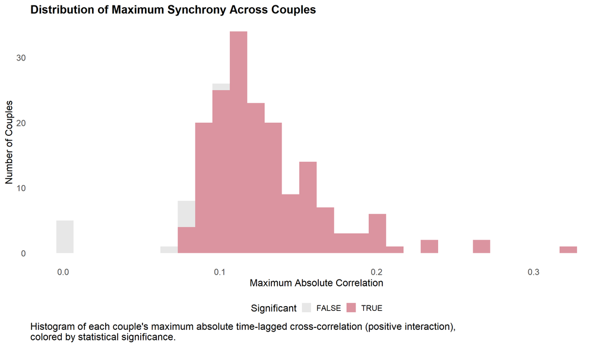

Figure 1

```r
# Distribution of lags where max occurs
blpwh_hist_lag <- ggplot(blpwh_sync_max_interpret, aes(x = max_lag, fill = leader)) +
  geom_histogram(binwidth = 1, alpha = 0.7) +
  scale_fill_manual(values = c("Mom leads" = "#88CCEE", "Partner leads" = "#CC6677", "Concurrent" = "#117733"), name = "Leader") +
  labs(title = "Lag at Maximum Synchrony",
       x = "Lag (seconds)",
       y = "Number of Couples",
       fill = "Leader",
       caption = str_wrap("Histogram of the time lag (in seconds) at which each couple's maximum synchrony occurs, colored by which partner leads.", width = 100)) +
  geom_vline(xintercept = 0, linetype = "dashed") +
  theme_minimal(base_size = 16) +
  theme(legend.position = "bottom", plot.title = element_text(face = "bold"),
        axis.title = element_text(size = 16), axis.text = element_text(size = 14),
        panel.grid = element_blank(),
        plot.caption = element_text(hjust = 0, size = 16))
```

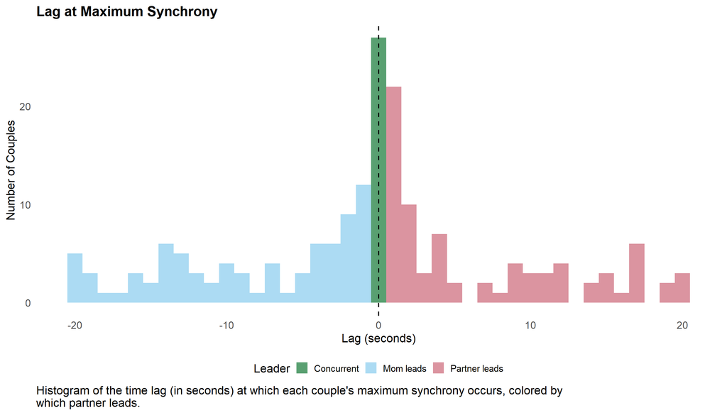

Figure 2

```r
# Scatterplot: max correlation vs lag
blpwh_scatter_sync <- ggplot(blpwh_sync_max_interpret,
       aes(x = max_lag, y = max_sync, color = significant)) +
  geom_point(size = 3, alpha = 0.6) +
  scale_color_manual(values = c("FALSE" = "#DDDDDD", "TRUE" = "#CC6677"), name = "Significant") +
  geom_hline(yintercept = 0, linetype = "dashed") +
  geom_vline(xintercept = 0, linetype = "dashed") +
  labs(title = "Maximum Synchrony: Correlation vs Lag",
       x = "Lag at Maximum (seconds)",
       y = "Correlation Coefficient",
       color = "Significant",
       caption = str_wrap("Each point is one couple's maximum correlation plotted against the lag at which it occurs, colored by statistical significance.", width = 100)) +
  theme_minimal(base_size = 16) +
  theme(legend.position = "bottom", plot.title = element_text(face = "bold"),
        axis.title = element_text(size = 16), axis.text = element_text(size = 14),
        panel.grid = element_blank(),
        plot.caption = element_text(hjust = 0, size = 16))
```

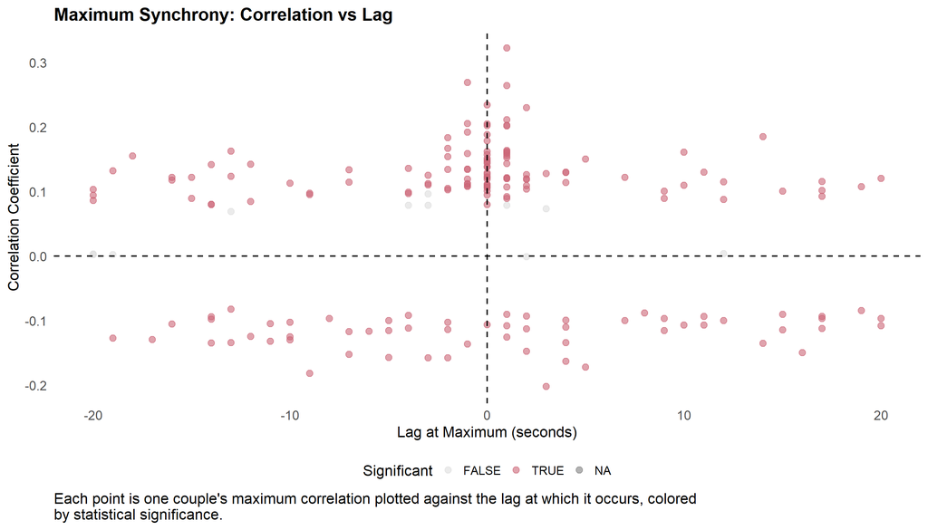

Figure 3

### Grid Panel

A closer look at a handful of individual couples’ full cross-correlation functions, rather than the summarized max-synchrony view above.

```r
# Show multiple couples in a grid
blpwh_sync_ccfplot <- function(blpwh_sync_results, n_couples = 12) {
  # Select specified couples for display
  selected_ids <- ccf_display_ids

  blpwh_sync_results %>%
    filter(ID %in% selected_ids) %>%
    ggplot(aes(x = lag, y = acf)) +
    geom_hline(yintercept = 0, linetype = "dashed", color = "#DDDDDD", size = 0.3) +
    geom_line(color = "#332288", size = 0.5) +
    geom_point(aes(color = significant), size = 1) +
    geom_ribbon(aes(ymin = lower_ci, ymax = upper_ci),
                alpha = 0.15, fill = "#332288") +
    scale_color_manual(values = c("FALSE" = "#DDDDDD", "TRUE" = "#CC6677"), name = "Significant") +
    facet_wrap(~ ID, scales = "free_y", ncol = 3) +
    labs(title = "Cross-Correlation Functions Across Couples",
         x = "Lag (seconds)",
         y = "Cross-Correlation",
         color = "Significant",
         caption = str_wrap("Full cross-correlation function by lag for a sample of couples, with 95% confidence bands and significant lags highlighted.", width = 100)) +
    theme_minimal(base_size = 16) +
    theme(legend.position = "bottom",
          strip.text = element_blank(),
          axis.title = element_text(size = 14), axis.text = element_text(size = 12),
          panel.grid = element_blank(),
          plot.caption = element_text(hjust = 0, size = 16))
}

# Make grid
blpwh_sync_ccfplot_p <- blpwh_sync_ccfplot(blpwh_sync_results, n_couples = 3)
```

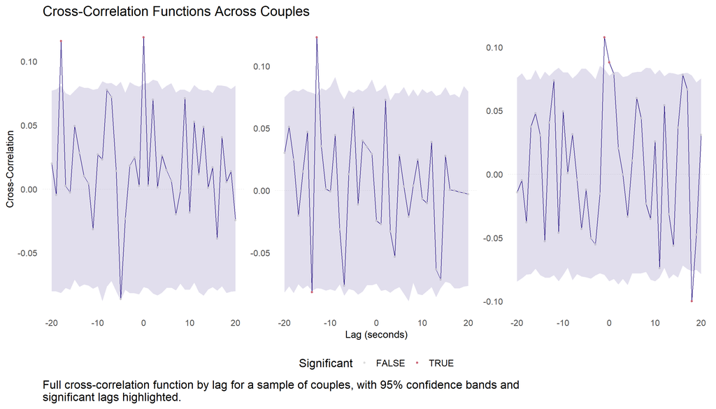

Figure 4

## Calculate Average

This collapses the couple-level CCFs into one sample-level average profile, showing the typical correlation at each lag across all couples along with the share of couples significant at that lag.

```r
# Compute mean CCF profile across all couples
blpwh_sync_avgccf <- blpwh_sync_results %>%
  group_by(lag) %>%
  summarise(
    mean_acf = mean(acf, na.rm = TRUE),
    se_acf = sd(acf, na.rm = TRUE) / sqrt(n()),
    lower_se = mean_acf - 1.96 * se_acf,
    upper_se = mean_acf + 1.96 * se_acf,
    pct_significant = mean(significant, na.rm = TRUE) * 100,
    .groups = "drop")
```

### Plot Average

The x-axis label below follows the same direction as everywhere else in this file: negative lags (left) are mom leading, positive lags (right) are partner leading.

```r
# Plot average CCF
blpwh_sync_avgccf_plot <- ggplot(blpwh_sync_avgccf, aes(x = lag, y = mean_acf)) +
  geom_hline(yintercept = 0, linetype = "dashed", color = "#DDDDDD") +
  geom_ribbon(aes(ymin = lower_se, ymax = upper_se),
              alpha = 0.3, fill = "#332288") +
  geom_line(color = "#332288", size = 1.2) +
  geom_point(aes(size = pct_significant), color = "#332288") +
  scale_size_continuous(range = c(1, 4), name = "% Couples\nSignificant") +
  labs(title = "Average Cross-Correlation Function Across All Couples",
       subtitle = "Shaded area represents 95% confidence interval",
       x = "Lag (seconds)\n\u2190 Mom leads | Partner leads \u2192",
       y = "Mean Cross-Correlation",
       caption = str_wrap("Mean cross-correlation function across all couples, with point size showing the percentage of couples significant at that lag.", width = 100)) +
  theme_minimal(base_size = 16) +
  theme(legend.position = "bottom", plot.title = element_text(face = "bold"),
        axis.title = element_text(size = 16), axis.text = element_text(size = 14),
        panel.grid = element_blank(),
        plot.caption = element_text(hjust = 0, size = 16))
```

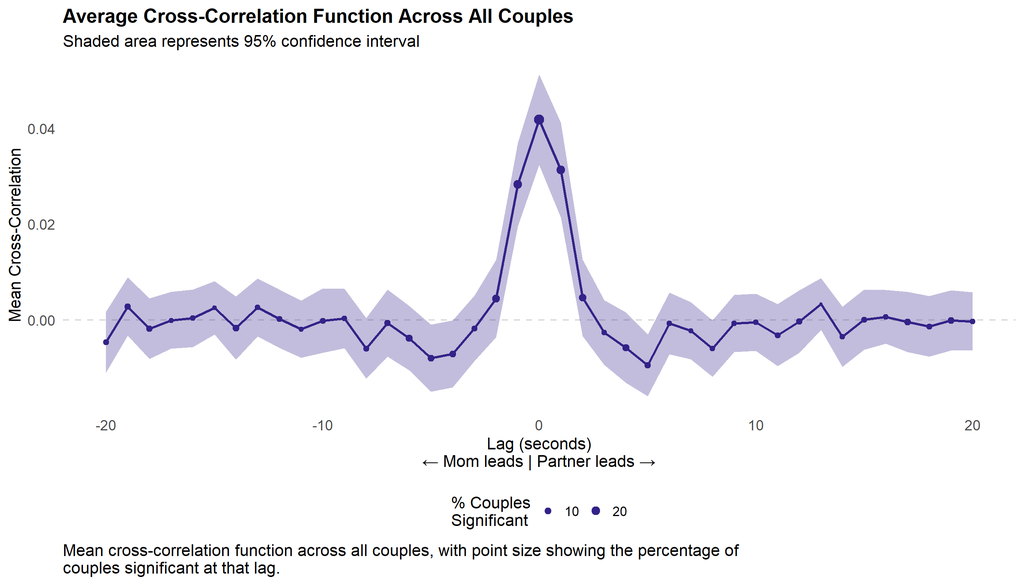

Figure 5

## Concurrent Synchrony

This isolates lag zero specifically: correlation between mom and partner at the exact same second, with no time offset in either direction.

```r
# Extract concurrent (lag = 0)
blpwh_sync_concurrent <- blpwh_sync_results %>%
  filter(lag == 0) %>%
  select(ID, concurrent_acf = acf, concurrent_sig = significant,
         concurrent_lower = lower_ci, concurrent_upper = upper_ci)

knitr::kable(anonymize_table_ids(head(blpwh_sync_concurrent, 10)), digits = 3, caption = str_wrap("Concurrent Synchrony, Positive Interaction (Randomized Couples, Fake IDs)", width = 100))
```

Concurrent Synchrony, Positive Interaction (Randomized Couples, Fake IDs)

| ID | concurrent_acf | concurrent_sig | concurrent_lower | concurrent_upper |
| --- | --- | --- | --- | --- |
| 6553 | 0.029 | FALSE | -0.080 | 0.088 |
| 9566 | 0.143 | TRUE | -0.081 | 0.085 |
| 5477 | 0.007 | FALSE | -0.081 | 0.084 |
| 5590 | 0.023 | FALSE | -0.076 | 0.081 |
| 8523 | 0.091 | TRUE | -0.078 | 0.082 |
| 8079 | 0.122 | TRUE | -0.078 | 0.080 |
| 7941 | 0.148 | TRUE | -0.081 | 0.079 |
| 1039 | -0.017 | FALSE | -0.083 | 0.083 |
| 1176 | 0.049 | FALSE | -0.073 | 0.079 |
| 4593 | 0.112 | TRUE | -0.079 | 0.083 |

## Time-Lagged

This restricts to non-zero lags and, separately, looks at how quickly synchrony first emerges for each couple.

```r
# Extract time-lagged (lag != 0)
blpwh_sync_lagged <- blpwh_sync_results %>% filter(lag != 0)

# Max synchrony across non-zero lags
blpwh_sync_lagmax <- blpwh_sync_lagged %>%
  group_by(ID) %>%
  # Find the row with maximum absolute correlation for each couple
  slice_max(abs(acf), n = 1, with_ties = FALSE) %>%
  select(ID,
         max_lag = lag,  # Lag at which max occurs
         max_sync = acf,  # Correlation value (with sign)
         max_abs_sync = acf,  # Will convert to absolute
         lower_ci,
         upper_ci,
         significant) %>%
  mutate(max_abs_sync = abs(max_sync)) %>%  # Add absolute value column
  ungroup()

# View results
knitr::kable(anonymize_table_ids(head(blpwh_sync_lagmax, 10)), digits = 3, caption = str_wrap("Maximum Time-Lagged Synchrony, Positive Interaction (Randomized Couples, Fake IDs)", width = 100))
```

Maximum Time-Lagged Synchrony, Positive Interaction (Randomized Couples, Fake IDs)

| ID | max_lag | max_sync | max_abs_sync | lower_ci | upper_ci | significant |
| --- | --- | --- | --- | --- | --- | --- |
| 6553 | -14 | 0.080 | 0.080 | -0.086 | 0.080 | TRUE |
| 9566 | -20 | -0.130 | 0.130 | -0.081 | 0.083 | TRUE |
| 5477 | -4 | -0.092 | 0.092 | -0.083 | 0.087 | TRUE |
| 5590 | 12 | 0.115 | 0.115 | -0.081 | 0.082 | TRUE |
| 8523 | -12 | 0.142 | 0.142 | -0.078 | 0.081 | TRUE |
| 8079 | 7 | -0.093 | 0.093 | -0.081 | 0.076 | TRUE |
| 7941 | -1 | 0.158 | 0.158 | -0.084 | 0.082 | TRUE |
| 1039 | 9 | -0.115 | 0.115 | -0.081 | 0.075 | TRUE |
| 1176 | -14 | -0.135 | 0.135 | -0.078 | 0.088 | TRUE |
| 4593 | 11 | 0.130 | 0.130 | -0.072 | 0.074 | TRUE |

```r
# Uses first sig lag
blpwh_sync_timetolag <- blpwh_sync_results %>%
  mutate(significant = as.vector(significant)) %>%
  filter(!is.na(significant)) %>%
  group_by(ID) %>%
  summarise(
    has_significant = any(significant, na.rm = TRUE),
    time_lag_to_sync = if (any(significant, na.rm = TRUE)) {
      abs(lag[which(significant)[1]])
    } else {
      NA_integer_
    },
    .groups = "drop"
  )

knitr::kable(anonymize_table_ids(head(blpwh_sync_timetolag, 10)), caption = str_wrap("Time to First Significant Synchrony, Positive Interaction (Randomized Couples, Fake IDs)", width = 100))
```

Time to First Significant Synchrony, Positive Interaction (Randomized Couples, Fake IDs)

| ID | has_significant | time_lag_to_sync |
| --- | --- | --- |
| 6553 | TRUE | 14 |
| 9566 | TRUE | 20 |
| 5477 | TRUE | 12 |
| 5590 | TRUE | 8 |
| 8523 | TRUE | 12 |
| 8079 | TRUE | 12 |
| 7941 | TRUE | 4 |
| 1039 | TRUE | 6 |
| 1176 | TRUE | 14 |
| 4593 | TRUE | 16 |

### Strongest Time-Lag

Among each couple’s significant lags only, this pulls the strongest one. The lag value has to be subset by `significant` before indexing with `which.max()`, since `which.max()` here returns a position within the significant-only subset, not within the full lag vector; indexing the full `lag` vector with that position (as the original code did) would pick the wrong lag whenever a couple has any non-significant lags before their strongest significant one. The `strongest_acf` line was already doing this correctly (subsetting `acf` before indexing), so `strongest_lag` is brought in line with it below.

```r
# Uses strongest sig lag
blpwh_sync_summary <- blpwh_sync_results %>%
  mutate(significant = as.vector(significant)) %>%
  filter(!is.na(significant)) %>%
  group_by(ID) %>%
  summarise(
    # Basic counts
    n_significant_lags = sum(significant),
    has_any_significant = any(significant),

    # If significant, what's the strongest? (lag subset by significant before indexing, to match acf below)
    strongest_lag = if(any(significant)) {
      lag[significant][which.max(abs(acf[significant]))]
    } else NA_real_,

    strongest_acf = if(any(significant)) {
      acf[significant][which.max(abs(acf[significant]))]
    } else NA_real_,

    # Specific patterns. Negative lag = mom leads, positive lag = partner leads
    has_concurrent = any(significant & lag == 0),
    has_mom_leads = any(significant & lag < 0),
    has_partner_leads = any(significant & lag > 0),

    .groups = "drop")
```

## Summary Table - IDs

```r
library(gt)
library(dplyr)

# ── Build Formatted Summary Table ─────────────────────────────────────────────
blpwh_sync_summarytable <- blpwh_sync_summary %>%
  # Select and order columns for display
  select(ID, n_significant_lags, strongest_lag, strongest_acf,
         has_concurrent, has_mom_leads, has_partner_leads) %>%
  anonymize_table_ids() %>%
  # Take first 20 couples for display (or use head(10) for fewer)
  head(20) %>%

  # Create gt table
  gt() %>%

  # Add title and subtitle
  tab_header(
    title = "Dyadic Synchrony Analysis",
    subtitle = "Cross-Correlation Results by Couple"
  ) %>%

  # Format numeric columns
  fmt_number(
    columns = c(strongest_acf),
    decimals = 3
  ) %>%
  fmt_number(
    columns = c(strongest_lag),
    decimals = 0
  ) %>%

  # Rename columns with readable labels
  cols_label(
    ID = "Couple ID",
    n_significant_lags = "# Significant Lags",
    strongest_lag = "Strongest Lag (sec)",
    strongest_acf = "Correlation (r)",
    has_concurrent = "Concurrent Sync",
    has_mom_leads = "Mom Leads",
    has_partner_leads = "Partner Leads"
  ) %>%

  # ── Encode Synchrony Indicators ───────────────────────────────────────────────
  data_color(
    columns = has_concurrent,
    colors = scales::col_factor(
      palette = c("#DDDDDD", "#117733"),
      domain = c(FALSE, TRUE)
    )
  ) %>%
  data_color(
    columns = has_mom_leads,
    colors = scales::col_factor(
      palette = c("#DDDDDD", "#88CCEE"),
      domain = c(FALSE, TRUE)
    )
  ) %>%
  data_color(
    columns = has_partner_leads,
    colors = scales::col_factor(
      palette = c("#DDDDDD", "#CC6677"),
      domain = c(FALSE, TRUE)
    )
  ) %>%

  # ── Encode Correlation Strength ───────────────────────────────────────────────
  data_color(
    columns = strongest_acf,
    colors = scales::col_numeric(
      palette = c("white", "#CC6677", "#332288"),
      domain = c(0, max(blpwh_sync_summary$strongest_acf, na.rm = TRUE))
    )
  ) %>%

  # ── Encode Lag Direction ──────────────────────────────────────────────────────
  data_color(
    columns = strongest_lag,
    colors = scales::col_numeric(
      palette = c("#88CCEE", "white", "#CC6677"),
      domain = c(
        min(blpwh_sync_summary$strongest_lag, na.rm = TRUE),
        max(blpwh_sync_summary$strongest_lag, na.rm = TRUE)
      )
    )
  ) %>%

  # Bold the column headers
  tab_style(
    style = list(
      cell_text(weight = "bold", color = "white"),
      cell_fill(color = "#CC6677")
    ),
    locations = cells_column_labels(everything())
  ) %>%

  # Style the title
  tab_style(
    style = cell_text(weight = "bold", size = "large"),
    locations = cells_title(groups = "title")
  ) %>%

  # Add alternating row colors
  tab_style(
    style = cell_fill(color = "#F5F5F5"),
    locations = cells_body(rows = seq(2, 20, 2))
  ) %>%

  # ── Add Interpretation Notes ──────────────────────────────────────────────────
  tab_footnote(
    footnote = "Significant lags determined by bootstrap confidence intervals (\u03b1 = .05)",
    locations = cells_column_labels(columns = n_significant_lags)
  ) %>%
  tab_footnote(
    footnote = "Negative lag = Mom leads; Positive lag = Partner leads; Zero = Concurrent",
    locations = cells_column_labels(columns = strongest_lag)
  ) %>%

  # Add source note
  tab_source_note(
    source_note = "Analysis based on pre-whitened ARIMA residuals with 1000 bootstrap iterations"
  ) %>%

  # Table size
  tab_options(
    table.font.size = px(14),
    column_labels.font.size = px(14),
    heading.title.font.size = px(16),
    heading.subtitle.font.size = px(13)
  ) %>%

  # Adjust column widths
  cols_width(
    ID ~ px(90),
    n_significant_lags ~ px(130),
    strongest_lag ~ px(140),
    strongest_acf ~ px(120),
    has_concurrent ~ px(120),
    has_mom_leads ~ px(120),
    has_partner_leads ~ px(140)
  )

# Display the table
blpwh_sync_summarytable
```

Dyadic Synchrony Analysis

Cross-Correlation Results by Couple

| Couple ID | # Significant Lags<sup>1</sup> | Strongest Lag (sec)<sup>2</sup> | Correlation (r) | Concurrent Sync | Mom Leads | Partner Leads |
| --- | --- | --- | --- | --- | --- | --- |
| 6553 | 1 | −14 | 0.080 | FALSE | TRUE | FALSE |
| 9566 | 5 | 0 | 0.143 | TRUE | TRUE | TRUE |
| 5477 | 3 | −4 | −0.092 | FALSE | TRUE | FALSE |
| 5590 | 5 | 12 | 0.115 | FALSE | TRUE | TRUE |
| 8523 | 5 | −12 | 0.142 | TRUE | TRUE | TRUE |
| 8079 | 5 | 0 | 0.122 | TRUE | TRUE | TRUE |
| 7941 | 5 | −1 | 0.158 | TRUE | TRUE | TRUE |
| 1039 | 5 | 9 | −0.115 | FALSE | TRUE | TRUE |
| 1176 | 2 | −14 | −0.135 | FALSE | TRUE | FALSE |
| 4593 | 6 | 11 | 0.130 | TRUE | TRUE | TRUE |
| 2205 | 2 | 0 | 0.119 | TRUE | TRUE | FALSE |
| 8576 | 6 | −7 | −0.117 | TRUE | TRUE | TRUE |
| 9386 | 4 | −9 | 0.095 | FALSE | TRUE | FALSE |
| 6644 | 4 | 12 | −0.100 | TRUE | TRUE | TRUE |
| 1673 | 3 | −1 | 0.112 | FALSE | TRUE | TRUE |
| 2683 | 1 | −10 | −0.103 | FALSE | TRUE | FALSE |
| 7225 | 3 | 1 | 0.121 | FALSE | FALSE | TRUE |
| 3740 | 2 | 20 | −0.097 | FALSE | FALSE | TRUE |
| 3270 | 3 | −2 | −0.103 | FALSE | TRUE | TRUE |
| 2757 | 2 | 9 | −0.097 | FALSE | FALSE | TRUE |

<sup>1</sup> Significant lags determined by bootstrap confidence intervals (α = .05)  
<sup>2</sup> Negative lag = Mom leads; Positive lag = Partner leads; Zero = Concurrent  
Analysis based on pre-whitened ARIMA residuals with 1000 bootstrap iterations

## Summary Table - All

```r
# ── Build Aggregate Summary Table ─────────────────────────────────────────────
blpwh_sync_summarystats <- blpwh_sync_summary %>%
  summarise(
    n_couples = n(),

    # Synchrony prevalence
    pct_any_significant = mean(has_any_significant, na.rm = TRUE) * 100,
    pct_concurrent = mean(has_concurrent, na.rm = TRUE) * 100,
    pct_mom_leads = mean(has_mom_leads, na.rm = TRUE) * 100,
    pct_partner_leads = mean(has_partner_leads, na.rm = TRUE) * 100,

    # Lag characteristics
    mean_n_sig_lags = mean(n_significant_lags, na.rm = TRUE),
    median_strongest_lag = median(strongest_lag, na.rm = TRUE),

    # Correlation strength
    mean_strongest_acf = mean(abs(strongest_acf), na.rm = TRUE),
    median_strongest_acf = median(abs(strongest_acf), na.rm = TRUE)
  ) %>%

  # Reshape for better display
  tidyr::pivot_longer(
    cols = everything(),
    names_to = "Metric",
    values_to = "Value"
  ) %>%

  # Create gt table
  gt() %>%
  tab_header(
    title = "Dyadic Synchrony: Summary Statistics",
    subtitle = paste0("N = ", nrow(blpwh_sync_summary), " couples")
  ) %>%

  # Format values
  fmt_number(
    columns = Value,
    decimals = 2
  ) %>%

  # Improve metric labels
  text_transform(
    locations = cells_body(columns = Metric),
    fn = function(x) {
      case_when(
        x == "n_couples" ~ "Total Couples",
        x == "pct_any_significant" ~ "% with Significant Synchrony",
        x == "pct_concurrent" ~ "% with Concurrent Synchrony",
        x == "pct_mom_leads" ~ "% with Mom Leading",
        x == "pct_partner_leads" ~ "% with Partner Leading",
        x == "mean_n_sig_lags" ~ "Mean # Significant Lags",
        x == "median_strongest_lag" ~ "Median Strongest Lag (sec)",
        x == "mean_strongest_acf" ~ "Mean Correlation Strength",
        x == "median_strongest_acf" ~ "Median Correlation Strength",
        TRUE ~ x
      )
    }
  ) %>%

  # Style
  tab_style(
    style = list(
      cell_text(weight = "bold", color = "white"),
      cell_fill(color = "#CC6677")
    ),
    locations = cells_column_labels(everything())
  ) %>%

  cols_label(
    Metric = "Statistic",
    Value = "Value"
  ) %>%

  tab_source_note(
    source_note = "Pre-whitened cross-correlation with bootstrap significance testing"
  )

# Display
blpwh_sync_summarystats
```

Dyadic Synchrony: Summary Statistics

N = 185 couples

| Statistic | Value |
| --- | --- |
| Total Couples | 185.00 |
| % with Significant Synchrony | 94.59 |
| % with Concurrent Synchrony | 29.19 |
| % with Mom Leading | 79.46 |
| % with Partner Leading | 74.05 |
| Mean # Significant Lags | 3.39 |
| Median Strongest Lag (sec) | 0.00 |
| Mean Correlation Strength | 0.13 |
| Median Correlation Strength | 0.12 |

Pre-whitened cross-correlation with bootstrap significance testing

## Compare Approaches

This lines up three different ways of summarizing a couple’s synchrony side by side: the time to the first significant lag, a simple mom-led/partner-led flag, and the single strongest significant lag. `mom_led` and `partner_led` replace the original `parent_led`/`infant_led` columns, which used parent-infant terminology left over from a different study’s template; this is a couple study, so the labels and the directions below both follow the mom/partner, negative-lag/positive-lag convention used throughout the rest of this file. The `strongest_lag` calculation has the same subset-before-index fix described above.

```r
# Compare the three approaches side-by-side for a few couples
blpwh_sync_compare <- blpwh_sync_results %>%
  mutate(significant = as.vector(significant)) %>%
  filter(!is.na(significant)) %>%
  group_by(ID) %>%
  summarise(
    # Approach 1: First significant lag
    first_sig_lag = if(any(significant)) abs(lag[which(significant)[1]]) else NA_real_,

    # Approach 2: Categorical. Negative lag = mom leads, positive lag = partner leads
    mom_led = any(significant & lag < 0),
    partner_led = any(significant & lag > 0),

    # Approach 3: Strongest (lag subset by significant before indexing, to match acf)
    strongest_lag = if(any(significant)) lag[significant][which.max(abs(acf[significant]))] else NA_real_,
    strongest_r = if(any(significant)) acf[significant][which.max(abs(acf[significant]))] else NA_real_,

    .groups = "drop"
  ) %>%
  head(10) %>%
  anonymize_table_ids() %>%

  gt() %>%
  tab_header(
    title = "Comparison of Three Synchrony Approaches",
    subtitle = "Randomized Couples, Fake IDs"
  ) %>%
  fmt_number(columns = c(first_sig_lag, strongest_lag), decimals = 0) %>%
  fmt_number(columns = strongest_r, decimals = 3) %>%
  cols_label(
    ID = "Couple",
    first_sig_lag = "First Sig Lag",
    mom_led = "Mom Led",
    partner_led = "Partner Led",
    strongest_lag = "Strongest Lag",
    strongest_r = "Strongest r"
  ) %>%
  tab_spanner(
    label = "Approach 1: First",
    columns = first_sig_lag
  ) %>%
  tab_spanner(
    label = "Approach 2: Categorical",
    columns = c(mom_led, partner_led)
  ) %>%
  tab_spanner(
    label = "Approach 3: Strongest",
    columns = c(strongest_lag, strongest_r)
  ) %>%
  tab_style(
    style = list(cell_text(weight = "bold", color = "white"),
                 cell_fill(color = "#CC6677")),
    locations = cells_column_labels(everything())
  ) %>%
  tab_style(
    style = list(cell_text(weight = "bold", color = "white"),
                 cell_fill(color = "#332288")),
    locations = cells_column_spanners(spanners = everything())
  )

blpwh_sync_compare
```

Comparison of Three Synchrony Approaches

Randomized Couples, Fake IDs

| Couple | Approach 1: First First Sig Lag | Approach 2: Categorical Mom Led | Approach 2: Categorical Partner Led | Approach 3: Strongest Strongest Lag | Approach 3: Strongest Strongest r |
| --- | --- | --- | --- | --- | --- |
| 6553 | 14 | TRUE | FALSE | −14 | 0.080 |
| 9566 | 20 | TRUE | TRUE | 0 | 0.143 |
| 5477 | 12 | TRUE | FALSE | −4 | −0.092 |
| 5590 | 8 | TRUE | TRUE | 12 | 0.115 |
| 8523 | 12 | TRUE | TRUE | −12 | 0.142 |
| 8079 | 12 | TRUE | TRUE | 0 | 0.122 |
| 7941 | 4 | TRUE | TRUE | −1 | 0.158 |
| 1039 | 6 | TRUE | TRUE | 9 | −0.115 |
| 1176 | 14 | TRUE | FALSE | −14 | −0.135 |
| 4593 | 16 | TRUE | TRUE | 11 | 0.130 |

# Negative Interaction

This section repeats the same synchrony calculation for negative warmth. The logic, the direction convention (negative lag, mom leads; positive lag, partner leads), and the corrected `strongest_lag` indexing are identical to the positive section above, so the narrative below stays brief.

## Synchrony Calculation

```r
# Function to compute time-lagged cross-correlation synchrony between dyad members
compute_blnwh_sync <- function(df, lag = 20, n_boot = 1000) {

  # Remove rows with missing data for both mom and partner variables
  df <- df %>% filter(!is.na(blmnwh), !is.na(blfnwh))

  # Check if there's enough data to compute lagged correlations
  if (nrow(df) < lag + 1) return(tibble(lag = NA, acf = NA, lower_ci = NA, upper_ci = NA, significant = NA))

  # ── Step 1: Pre-Whiten Each Partner Series ──────────────────────────────
  # Fit ARIMA models to each person's time series to account for their individual temporal patterns
  fit_mom <- tryCatch(auto.arima(df$blmnwh), error = function(e) NULL)
  fit_partner <- tryCatch(auto.arima(df$blfnwh), error = function(e) NULL)

  # If either model fails, return NA results
  if (is.null(fit_mom) || is.null(fit_partner)) return(tibble(lag = NA, acf = NA, lower_ci = NA, upper_ci = NA, significant = NA))

  # Extract residuals (pre-whitened series) - these represent deviations from each person's own temporal pattern
  res_mom <- residuals(fit_mom)
  res_partner <- residuals(fit_partner)

  # Combine residuals and remove any remaining missing values
  residuals_df <- tibble(res_mom, res_partner) %>% drop_na()
  if (nrow(residuals_df) < lag + 1) return(tibble(lag = NA, acf = NA, lower_ci = NA, upper_ci = NA, significant = NA))

  # ── Step 2: Compute Observed Cross-Correlation ──────────────────────────
  # Ccf(mom, partner)[k] estimates cor(mom[t+k], partner[t])
  # Negative lags: mom leads partner. Positive lags: partner leads mom. Same convention as the positive section above
  ccf_result <- ccf(residuals_df$res_mom, residuals_df$res_partner, lag.max = lag, plot = FALSE)
  observed_acf <- ccf_result$acf  # Cross-correlation values at each lag
  lags <- ccf_result$lag  # Lag values (e.g., -20 to +20)

  # ── Step 3: Bootstrap the Null Distribution ─────────────────────────────
  # Create matrix to store bootstrap results
  boot_corrs <- matrix(NA, nrow = n_boot, ncol = length(lags))
  n <- nrow(residuals_df)

  # Generate null distribution by randomly shuffling residuals (breaks temporal coupling)
  for (i in 1:n_boot) {
    x_boot <- sample(residuals_df$res_mom, n, replace = TRUE)  # Resample mom's residuals
    y_boot <- sample(residuals_df$res_partner, n, replace = TRUE)  # Resample partner's residuals
    boot_ccf <- ccf(x_boot, y_boot, lag.max = lag, plot = FALSE)  # Compute CCF on shuffled data
    boot_corrs[i, ] <- boot_ccf$acf  # Store correlation values
  }

  # Calculate 95% confidence intervals from bootstrap distribution
  lower_ci <- apply(boot_corrs, 2, quantile, probs = 0.025, na.rm = TRUE)
  upper_ci <- apply(boot_corrs, 2, quantile, probs = 0.975, na.rm = TRUE)

  # Determine significance: observed correlation falls outside 95% CI
  significant <- (observed_acf < lower_ci) | (observed_acf > upper_ci)

  # Return tibble with lag values, correlations, CIs, and significance
  tibble(
    lag = as.numeric(lags),
    acf = as.numeric(observed_acf),
    lower_ci = lower_ci,
    upper_ci = upper_ci,
    significant = significant
  )
}
```

```r
# Nest data by couple ID (creates list-column with each dyad's time series)
blnwh_sync_id <- BL_WH_Long %>%
  group_by(ID) %>%
  nest()

# Apply the synchrony function to each couple's data
blnwh_sync_id <- blnwh_sync_id %>%
  mutate(blnwh_sync_ccf = map(data, compute_blnwh_sync))

# Unnest results to get one row per couple per lag value
blnwh_sync_results <- unnest(blnwh_sync_id, blnwh_sync_ccf)

blnwh_sync_results$lag <- as.numeric(blnwh_sync_results$lag)
```

## Max Synchrony

```r
# Extract max synchrony for each couple
blnwh_sync_max <- blnwh_sync_results %>%
  group_by(ID) %>%
  # Find the row with maximum absolute correlation for each couple
  slice_max(abs(acf), n = 1, with_ties = FALSE) %>%
  select(ID,
         max_lag = lag,  # Lag at which max occurs
         max_sync = acf,  # Correlation value (with sign)
         max_abs_sync = acf,  # Will convert to absolute
         lower_ci,
         upper_ci,
         significant) %>%
  mutate(max_abs_sync = abs(max_sync)) %>%  # Add absolute value column
  ungroup()

knitr::kable(anonymize_table_ids(head(blnwh_sync_max, 10)), digits = 3, caption = str_wrap("Maximum Synchrony, Negative Interaction (Randomized Couples, Fake IDs)", width = 100))
```

Maximum Synchrony, Negative Interaction (Randomized Couples, Fake IDs)

| ID | max_lag | max_sync | max_abs_sync | lower_ci | upper_ci | significant |
| --- | --- | --- | --- | --- | --- | --- |
| 6553 | 2 | 0.133 | 0.133 | -0.093 | 0.079 | TRUE |
| 9566 | -20 | 0.126 | 0.126 | -0.081 | 0.080 | TRUE |
| 5477 | NA | NA | NA | NA | NA | NA |
| 5590 | 3 | 0.173 | 0.173 | -0.080 | 0.084 | TRUE |
| 8523 | 0 | 0.155 | 0.155 | -0.088 | 0.079 | TRUE |
| 8079 | 5 | -0.114 | 0.114 | -0.085 | 0.072 | TRUE |
| 7941 | -1 | 0.119 | 0.119 | -0.082 | 0.081 | TRUE |
| 1039 | -11 | 0.180 | 0.180 | -0.085 | 0.087 | TRUE |
| 1176 | 3 | -0.124 | 0.124 | -0.081 | 0.081 | TRUE |
| 4593 | 0 | 0.188 | 0.188 | -0.082 | 0.084 | TRUE |

### Max Synchrony Interpretation

```r
# Add interpretation columns
blnwh_sync_max_interpret <- blnwh_sync_max %>%
  mutate(
    # Who leads? Negative lag = mom leads, positive lag = partner leads (see Positive Interaction section)
    leader = case_when(
      max_lag < 0 ~ "Mom leads",
      max_lag > 0 ~ "Partner leads",
      max_lag == 0 ~ "Concurrent",
      TRUE ~ NA_character_
    ),
    # Leader numerical
    leaderN = case_when(
      max_lag < 0 ~ "1" ,  # Mom
      max_lag > 0 ~ "2" ,  # Partner
      max_lag == 0 ~ "3",  # Concurrent
      TRUE ~ NA_character_
    ),
    # How much lead time?
    lead_time_seconds = abs(max_lag),
    # Direction of relationship
    relationship = case_when(
      max_sync > 0 ~ "Positive (same direction)",
      max_sync < 0 ~ "Negative (opposite direction)",
      TRUE ~ NA_character_
    ),
    # Strength categorization (example thresholds)
    strength = case_when(
      max_abs_sync >= 0.5 ~ "Strong",
      max_abs_sync >= 0.3 ~ "Moderate",
      max_abs_sync >= 0.1 ~ "Weak",
      TRUE ~ "Very weak"
    )
  )

# View interpreted results
blnwh_sync_max_interpret_preview <- blnwh_sync_max_interpret %>%
  select(ID, max_sync, max_lag, leader, lead_time_seconds,
         relationship, strength, significant)

knitr::kable(anonymize_table_ids(head(blnwh_sync_max_interpret_preview, 10)), digits = 3, caption = str_wrap("Interpreted Maximum Synchrony, Negative Interaction (Randomized Couples, Fake IDs)", width = 100))
```

Interpreted Maximum Synchrony, Negative Interaction (Randomized Couples, Fake IDs)

| ID | max_sync | max_lag | leader | lead_time_seconds | relationship | strength | significant |
| --- | --- | --- | --- | --- | --- | --- | --- |
| 6553 | 0.133 | 2 | Partner leads | 2 | Positive (same direction) | Weak | TRUE |
| 9566 | 0.126 | -20 | Mom leads | 20 | Positive (same direction) | Weak | TRUE |
| 5477 | NA | NA | NA | NA | NA | Very weak | NA |
| 5590 | 0.173 | 3 | Partner leads | 3 | Positive (same direction) | Weak | TRUE |
| 8523 | 0.155 | 0 | Concurrent | 0 | Positive (same direction) | Weak | TRUE |
| 8079 | -0.114 | 5 | Partner leads | 5 | Negative (opposite direction) | Weak | TRUE |
| 7941 | 0.119 | -1 | Mom leads | 1 | Positive (same direction) | Weak | TRUE |
| 1039 | 0.180 | -11 | Mom leads | 11 | Positive (same direction) | Weak | TRUE |
| 1176 | -0.124 | 3 | Partner leads | 3 | Negative (opposite direction) | Weak | TRUE |
| 4593 | 0.188 | 0 | Concurrent | 0 | Positive (same direction) | Weak | TRUE |

## Descriptives

```r
# Descriptive statistics across all couples
blnwh_sync_max_interpret_summary <- blnwh_sync_max_interpret %>%
  summarise(
    n_couples = n(),
    n_significant = sum(significant, na.rm = TRUE),
    pct_significant = mean(significant, na.rm = TRUE) * 100,

    mean_max_sync = mean(max_abs_sync, na.rm = TRUE),
    sd_max_sync = sd(max_abs_sync, na.rm = TRUE),

    mean_lag = mean(max_lag, na.rm = TRUE),
    sd_lag = sd(max_lag, na.rm = TRUE),

    # Negative lag = mom leads, positive lag = partner leads
    n_mom_leads = sum(max_lag < 0, na.rm = TRUE),
    n_partner_leads = sum(max_lag > 0, na.rm = TRUE),
    n_concurrent = sum(max_lag == 0, na.rm = TRUE),

    n_positive = sum(max_sync > 0, na.rm = TRUE),
    n_negative = sum(max_sync < 0, na.rm = TRUE)
  )

knitr::kable(blnwh_sync_max_interpret_summary, digits = 2, caption = str_wrap("Descriptive Summary of Maximum Synchrony, Negative Interaction", width = 100))
```

Descriptive Summary of Maximum Synchrony, Negative Interaction

| n_couples | n_significant | pct_significant | mean_max_sync | sd_max_sync | mean_lag | sd_lag | n_mom_leads | n_partner_leads | n_concurrent | n_positive | n_negative |
| --- | --- | --- | --- | --- | --- | --- | --- | --- | --- | --- | --- |
| 188 | 152 | 91.02 | 0.16 | 0.08 | -0.91 | 10 | 78 | 78 | 23 | 116 | 51 |

## Plot Max Synchrony

```r
library(ggplot2)

# Distribution of maximum synchrony values
blnwh_hist_maxsync <- ggplot(blnwh_sync_max_interpret, aes(x = max_abs_sync, fill = significant)) +
  geom_histogram(bins = 30, alpha = 0.7) +
  scale_fill_manual(values = c("FALSE" = "#DDDDDD", "TRUE" = "#CC6677"), name = "Significant") +
  labs(title = "Distribution of Maximum Synchrony Across Couples",
       x = "Maximum Absolute Correlation",
       y = "Number of Couples",
       fill = "Significant",
       caption = str_wrap("Histogram of each couple's maximum absolute time-lagged cross-correlation (negative interaction), colored by statistical significance.", width = 100)) +
  theme_minimal(base_size = 16) +
  theme(legend.position = "bottom", plot.title = element_text(face = "bold"),
        axis.title = element_text(size = 16), axis.text = element_text(size = 14),
        panel.grid = element_blank(),
        plot.caption = element_text(hjust = 0, size = 16))
```

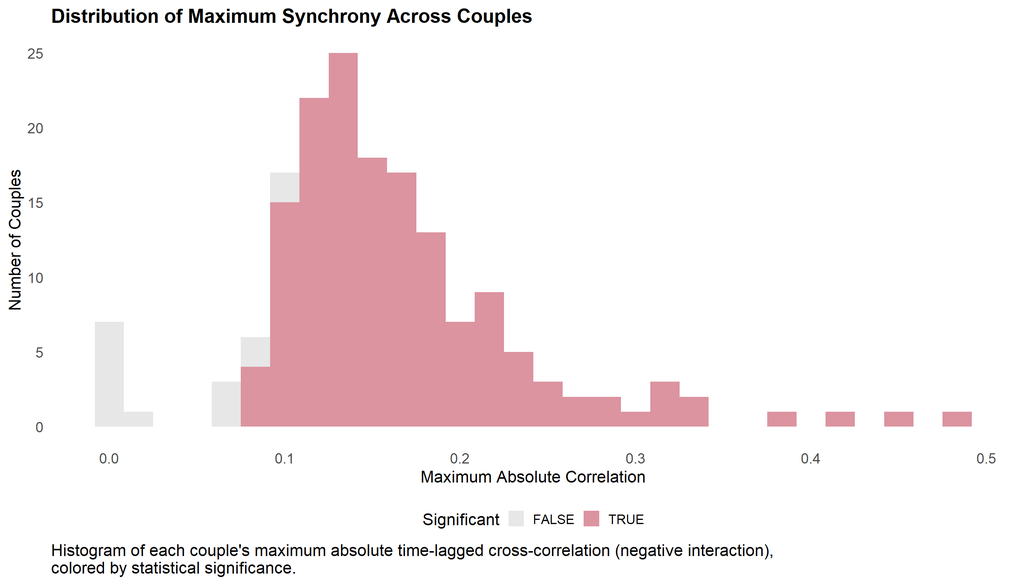

Figure 6

[figure not shown]

```r
# Distribution of lags where max occurs
blnwh_hist_lag <- ggplot(blnwh_sync_max_interpret, aes(x = max_lag, fill = leader)) +
  geom_histogram(binwidth = 1, alpha = 0.7) +
  scale_fill_manual(values = c("Mom leads" = "#88CCEE", "Partner leads" = "#CC6677", "Concurrent" = "#117733"), name = "Leader") +
  labs(title = "Lag at Maximum Synchrony",
       x = "Lag (seconds)",
       y = "Number of Couples",
       fill = "Leader",
       caption = str_wrap("Histogram of the time lag (in seconds) at which each couple's maximum synchrony occurs, colored by which partner leads.", width = 100)) +
  geom_vline(xintercept = 0, linetype = "dashed") +
  theme_minimal(base_size = 16) +
  theme(legend.position = "bottom", plot.title = element_text(face = "bold"),
        axis.title = element_text(size = 16), axis.text = element_text(size = 14),
        panel.grid = element_blank(),
        plot.caption = element_text(hjust = 0, size = 16))
blnwh_hist_lag
```

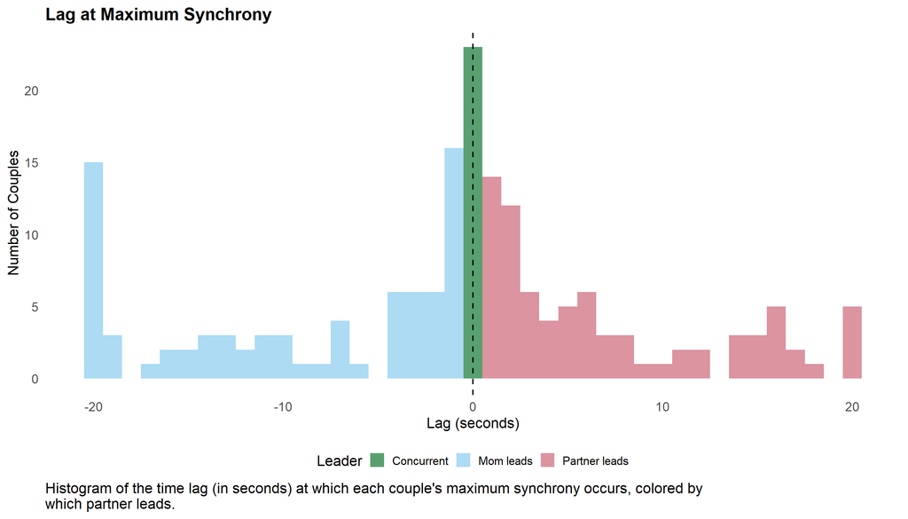

Figure 7

```r
# Scatterplot: max correlation vs lag
blnwh_scatter_sync <- ggplot(blnwh_sync_max_interpret,
       aes(x = max_lag, y = max_sync, color = significant)) +
  geom_point(size = 3, alpha = 0.6) +
  scale_color_manual(values = c("FALSE" = "#DDDDDD", "TRUE" = "#CC6677"), name = "Significant") +
  geom_hline(yintercept = 0, linetype = "dashed") +
  geom_vline(xintercept = 0, linetype = "dashed") +
  labs(title = "Maximum Synchrony: Correlation vs Lag",
       x = "Lag at Maximum (seconds)",
       y = "Correlation Coefficient",
       color = "Significant",
       caption = str_wrap("Each point is one couple's maximum correlation plotted against the lag at which it occurs, colored by statistical significance.", width = 100)) +
  theme_minimal(base_size = 16) +
  theme(legend.position = "bottom", plot.title = element_text(face = "bold"),
        axis.title = element_text(size = 16), axis.text = element_text(size = 14),
        panel.grid = element_blank(),
        plot.caption = element_text(hjust = 0, size = 16))
```

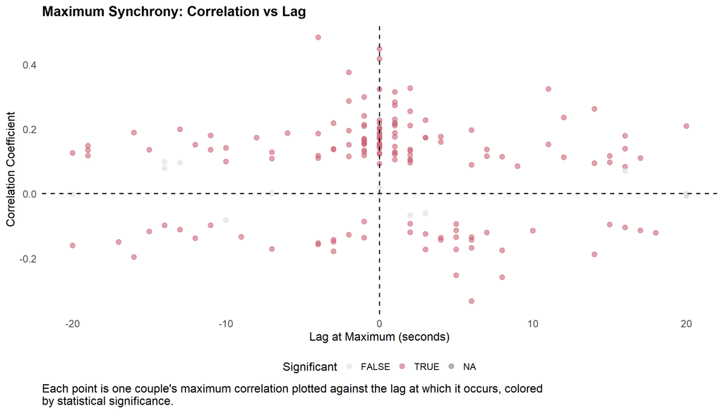

Figure 8

### Grid Panel

```r
# Show multiple couples in a grid
blnwh_sync_ccfplot <- function(blnwh_sync_results, n_couples = 12) {
  # Select specified couples for display
  selected_ids <- ccf_display_ids

  blnwh_sync_results %>%
    filter(ID %in% selected_ids) %>%
    ggplot(aes(x = lag, y = acf)) +
    geom_hline(yintercept = 0, linetype = "dashed", color = "#DDDDDD", size = 0.3) +
    geom_line(color = "#332288", size = 0.5) +
    geom_point(aes(color = significant), size = 1) +
    geom_ribbon(aes(ymin = lower_ci, ymax = upper_ci),
                alpha = 0.15, fill = "#332288") +
    scale_color_manual(values = c("FALSE" = "#DDDDDD", "TRUE" = "#CC6677"), name = "Significant") +
    facet_wrap(~ ID, scales = "free_y", ncol = 3) +
    labs(title = "Cross-Correlation Functions Across Couples",
         x = "Lag (seconds)",
         y = "Cross-Correlation",
         color = "Significant",
         caption = str_wrap("Full cross-correlation function by lag for a sample of couples, with 95% confidence bands and significant lags highlighted.", width = 100)) +
    theme_minimal(base_size = 16) +
    theme(legend.position = "bottom",
          strip.text = element_blank(),
          axis.title = element_text(size = 14), axis.text = element_text(size = 12),
          panel.grid = element_blank(),
          plot.caption = element_text(hjust = 0, size = 16))
}

# Make grid
blnwh_sync_ccfplot_p <- blnwh_sync_ccfplot(blnwh_sync_results, n_couples = 3)
```

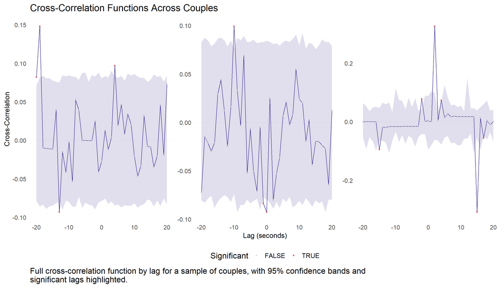

Figure 9

## Calculate Average

```r
# Compute mean CCF profile across all couples
blnwh_sync_avgccf <- blnwh_sync_results %>%
  group_by(lag) %>%
  summarise(
    mean_acf = mean(acf, na.rm = TRUE),
    se_acf = sd(acf, na.rm = TRUE) / sqrt(n()),
    lower_se = mean_acf - 1.96 * se_acf,
    upper_se = mean_acf + 1.96 * se_acf,
    pct_significant = mean(significant, na.rm = TRUE) * 100,
    .groups = "drop"
  )
```

### Plot Average

```r
# Plot average CCF
blnwh_sync_avgccf_plot <- ggplot(blnwh_sync_avgccf, aes(x = lag, y = mean_acf)) +
  geom_hline(yintercept = 0, linetype = "dashed", color = "#DDDDDD") +
  geom_ribbon(aes(ymin = lower_se, ymax = upper_se),
              alpha = 0.3, fill = "#332288") +
  geom_line(color = "#332288", size = 1.2) +
  geom_point(aes(size = pct_significant), color = "#332288") +
  scale_size_continuous(range = c(1, 4), name = "% Couples\nSignificant") +
  labs(title = "Average Cross-Correlation Function Across All Couples",
       subtitle = "Shaded area represents 95% confidence interval",
       x = "Lag (seconds)\n\u2190 Mom leads | Partner leads \u2192",
       y = "Mean Cross-Correlation",
       caption = str_wrap("Mean cross-correlation function across all couples, with point size showing the percentage of couples significant at that lag.", width = 100)) +
  theme_minimal(base_size = 16) +
  theme(legend.position = "bottom", plot.title = element_text(face = "bold"),
        axis.title = element_text(size = 16), axis.text = element_text(size = 14),
        panel.grid = element_blank(),
        plot.caption = element_text(hjust = 0, size = 16))
```

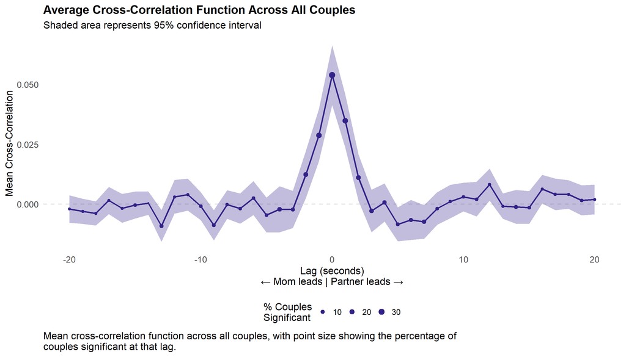

Figure 10

### Heatmap Across Couples

Couples are identified only by their row order, not their real ID, and the y-axis is left unlabeled, so no participant identifiers appear on the public site. The blue-to-rose gradient here already matches the Tol palette and the mom-leads (blue) / partner-leads (rose) convention used everywhere else in this file, so it’s unchanged.

```r
# Heatmap showing all couples' CCF profiles
blnwh_sync_heatmap <- function(blnwh_sync_results, n_couples = 50) {
  selected_ids <- unique(blnwh_sync_results$ID)[1:min(n_couples, length(unique(blnwh_sync_results$ID)))]

  blnwh_sync_results %>%
    filter(ID %in% selected_ids) %>%
    mutate(couple_row = factor(match(ID, selected_ids))) %>%
    ggplot(aes(x = lag, y = couple_row, fill = acf)) +
    geom_tile() +
    scale_fill_gradient2(low = "#88CCEE", mid = "#DDDDDD", high = "#CC6677",
                         midpoint = 0, limits = c(-1, 1),
                         name = "Correlation") +
    labs(title = "Cross-Correlation Heatmap: Random Assortment of Couples in the Study",
         x = "Lag (seconds)",
         y = NULL,
         caption = str_wrap("Correlation at every lag for a random assortment of couples in the study; couples are not individually identified. Red indicates positive correlation, blue negative, centered at zero.", width = 100)) +
    theme_minimal(base_size = 16) +
    theme(legend.position = "bottom", axis.title = element_text(size = 14),
          axis.text.y = element_blank(), axis.ticks.y = element_blank(),
          axis.text.x = element_text(size = 12),
          panel.grid = element_blank(),
          plot.caption = element_text(hjust = 0, size = 16))
}

blnwh_sync_heatmap_p <- blnwh_sync_heatmap(blnwh_sync_results, n_couples = 30)
```

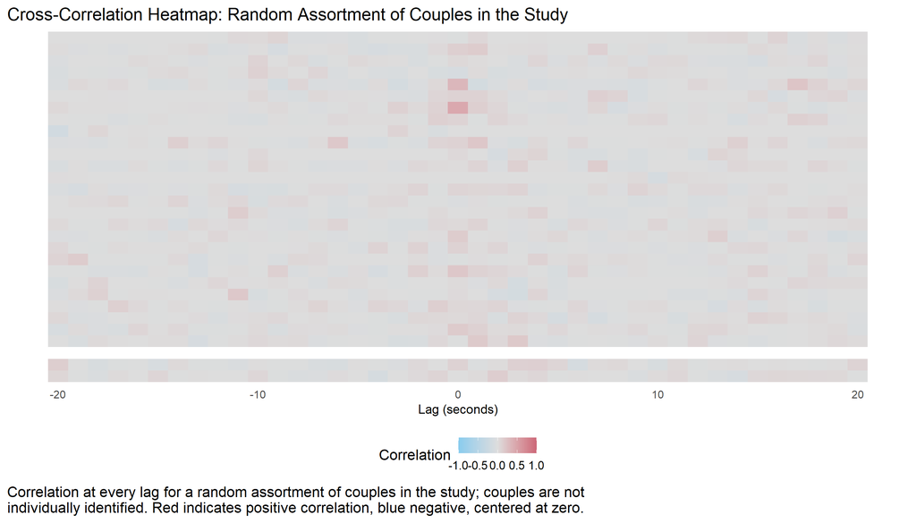

Figure 11

## Concurrent Synchrony

```r
# Extract concurrent (lag = 0)
blnwh_sync_concurrent <- blnwh_sync_results %>%
  filter(lag == 0) %>%
  select(ID, concurrent_acf = acf, concurrent_sig = significant,
         concurrent_lower = lower_ci, concurrent_upper = upper_ci)

knitr::kable(anonymize_table_ids(head(blnwh_sync_concurrent, 10)), digits = 3, caption = str_wrap("Concurrent Synchrony, Negative Interaction (Randomized Couples, Fake IDs)", width = 100))
```

Concurrent Synchrony, Negative Interaction (Randomized Couples, Fake IDs)

| ID | concurrent_acf | concurrent_sig | concurrent_lower | concurrent_upper |
| --- | --- | --- | --- | --- |
| 6553 | 0.000 | FALSE | -0.086 | 0.084 |
| 9566 | 0.096 | TRUE | -0.086 | 0.079 |
| 5590 | -0.016 | FALSE | -0.092 | 0.076 |
| 8523 | 0.155 | TRUE | -0.088 | 0.079 |
| 8079 | 0.038 | FALSE | -0.080 | 0.078 |
| 7941 | 0.054 | FALSE | -0.080 | 0.085 |
| 1039 | 0.030 | FALSE | -0.086 | 0.086 |
| 1176 | 0.029 | FALSE | -0.080 | 0.076 |
| 4593 | 0.188 | TRUE | -0.082 | 0.084 |
| 2205 | -0.027 | FALSE | -0.079 | 0.080 |

## Time Lagged Synchrony

```r
# Extract time-lagged (lag != 0)
blnwh_sync_lagged <- blnwh_sync_results %>% filter(lag != 0)

# Max synchrony across non-zero lags
blnwh_sync_lagmax <- blnwh_sync_lagged %>%
  group_by(ID) %>%
  # Find the row with maximum absolute correlation for each couple
  slice_max(abs(acf), n = 1, with_ties = FALSE) %>%
  select(ID,
         max_lag = lag,  # Lag at which max occurs
         max_sync = acf,  # Correlation value (with sign)
         max_abs_sync = acf,  # Will convert to absolute
         lower_ci,
         upper_ci,
         significant) %>%
  mutate(max_abs_sync = abs(max_sync)) %>%  # Add absolute value column
  ungroup()

# View results
knitr::kable(anonymize_table_ids(head(blnwh_sync_lagmax, 10)), digits = 3, caption = str_wrap("Maximum Time-Lagged Synchrony, Negative Interaction (Randomized Couples, Fake IDs)", width = 100))
```

Maximum Time-Lagged Synchrony, Negative Interaction (Randomized Couples, Fake IDs)

| ID | max_lag | max_sync | max_abs_sync | lower_ci | upper_ci | significant |
| --- | --- | --- | --- | --- | --- | --- |
| 6553 | 2 | 0.133 | 0.133 | -0.093 | 0.079 | TRUE |
| 9566 | -20 | 0.126 | 0.126 | -0.081 | 0.080 | TRUE |
| 5590 | 3 | 0.173 | 0.173 | -0.080 | 0.084 | TRUE |
| 8523 | 1 | 0.102 | 0.102 | -0.085 | 0.077 | TRUE |
| 8079 | 5 | -0.114 | 0.114 | -0.085 | 0.072 | TRUE |
| 7941 | -1 | 0.119 | 0.119 | -0.082 | 0.081 | TRUE |
| 1039 | -11 | 0.180 | 0.180 | -0.085 | 0.087 | TRUE |
| 1176 | 3 | -0.124 | 0.124 | -0.081 | 0.081 | TRUE |
| 4593 | -2 | 0.114 | 0.114 | -0.081 | 0.087 | TRUE |
| 2205 | -19 | 0.148 | 0.148 | -0.086 | 0.082 | TRUE |

```r
# Uses first sig lag
blnwh_sync_timetolag <- blnwh_sync_results %>%
  mutate(significant = as.vector(significant)) %>%
  filter(!is.na(significant)) %>%
  group_by(ID) %>%
  summarise(
    has_significant = any(significant, na.rm = TRUE),
    time_lag_to_sync = if (any(significant, na.rm = TRUE)) {
      abs(lag[which(significant)[1]])
    } else {
      NA_integer_
    },
    .groups = "drop"
  )

knitr::kable(anonymize_table_ids(head(blnwh_sync_timetolag, 10)), caption = str_wrap("Time to First Significant Synchrony, Negative Interaction (Randomized Couples, Fake IDs)", width = 100))
```

Time to First Significant Synchrony, Negative Interaction (Randomized Couples, Fake IDs)

| ID | has_significant | time_lag_to_sync |
| --- | --- | --- |
| 6553 | TRUE | 4 |
| 9566 | TRUE | 20 |
| 5590 | TRUE | 13 |
| 8523 | TRUE | 20 |
| 8079 | TRUE | 5 |
| 7941 | TRUE | 17 |
| 1039 | TRUE | 18 |
| 1176 | TRUE | 18 |
| 4593 | TRUE | 13 |
| 2205 | TRUE | 20 |

## Summary Table - ID

Same subset-before-index correction to `strongest_lag` as the positive section.

```r
# Uses strongest sig lag
blnwh_sync_summary <- blnwh_sync_results %>%
  mutate(significant = as.vector(significant)) %>%
  filter(!is.na(significant)) %>%
  group_by(ID) %>%
  summarise(
    # Basic counts
    n_significant_lags = sum(significant),
    has_any_significant = any(significant),

    # If significant, what's the strongest? (lag subset by significant before indexing, to match acf below)
    strongest_lag = if(any(significant)) {
      lag[significant][which.max(abs(acf[significant]))]
    } else NA_real_,

    strongest_acf = if(any(significant)) {
      acf[significant][which.max(abs(acf[significant]))]
    } else NA_real_,

    # Specific patterns. Negative lag = mom leads, positive lag = partner leads
    has_concurrent = any(significant & lag == 0),
    has_mom_leads = any(significant & lag < 0),
    has_partner_leads = any(significant & lag > 0),

    .groups = "drop"
  )
```

## Summary Table - All

```r
library(gt)
library(dplyr)

# ── Build Formatted Summary Table ─────────────────────────────────────────────
blnwh_sync_summarytable <- blnwh_sync_summary %>%
  # Select and order columns for display
  select(ID, n_significant_lags, strongest_lag, strongest_acf,
         has_concurrent, has_mom_leads, has_partner_leads) %>%
  anonymize_table_ids() %>%
  # Take first 20 couples for display (or use head(10) for fewer)
  head(20) %>%

  # Create gt table
  gt() %>%

  # Add title and subtitle
  tab_header(
    title = "Dyadic Synchrony Analysis",
    subtitle = "Cross-Correlation Results by Couple"
  ) %>%

  # Format numeric columns
  fmt_number(
    columns = c(strongest_acf),
    decimals = 3
  ) %>%
  fmt_number(
    columns = c(strongest_lag),
    decimals = 0
  ) %>%

  # Rename columns with readable labels
  cols_label(
    ID = "Couple ID",
    n_significant_lags = "# Significant Lags",
    strongest_lag = "Strongest Lag (sec)",
    strongest_acf = "Correlation (r)",
    has_concurrent = "Concurrent Sync",
    has_mom_leads = "Mom Leads",
    has_partner_leads = "Partner Leads"
  ) %>%

  # ── Encode Synchrony Indicators ───────────────────────────────────────────────
  data_color(
    columns = has_concurrent,
    colors = scales::col_factor(
      palette = c("#DDDDDD", "#117733"),
      domain = c(FALSE, TRUE)
    )
  ) %>%
  data_color(
    columns = has_mom_leads,
    colors = scales::col_factor(
      palette = c("#DDDDDD", "#88CCEE"),
      domain = c(FALSE, TRUE)
    )
  ) %>%
  data_color(
    columns = has_partner_leads,
    colors = scales::col_factor(
      palette = c("#DDDDDD", "#CC6677"),
      domain = c(FALSE, TRUE)
    )
  ) %>%

  # ── Encode Correlation Strength ───────────────────────────────────────────────
  data_color(
    columns = strongest_acf,
    colors = scales::col_numeric(
      palette = c("white", "#CC6677", "#332288"),
      domain = c(0, max(blnwh_sync_summary$strongest_acf, na.rm = TRUE))
    )
  ) %>%

  # ── Encode Lag Direction ──────────────────────────────────────────────────────
  data_color(
    columns = strongest_lag,
    colors = scales::col_numeric(
      palette = c("#88CCEE", "white", "#CC6677"),
      domain = c(
        min(blnwh_sync_summary$strongest_lag, na.rm = TRUE),
        max(blnwh_sync_summary$strongest_lag, na.rm = TRUE)
      )
    )
  ) %>%

  # Bold the column headers
  tab_style(
    style = list(
      cell_text(weight = "bold", color = "white"),
      cell_fill(color = "#CC6677")
    ),
    locations = cells_column_labels(everything())
  ) %>%

  # Style the title
  tab_style(
    style = cell_text(weight = "bold", size = "large"),
    locations = cells_title(groups = "title")
  ) %>%

  # Add alternating row colors
  tab_style(
    style = cell_fill(color = "#F5F5F5"),
    locations = cells_body(rows = seq(2, 20, 2))
  ) %>%

  # ── Add Interpretation Notes ──────────────────────────────────────────────────
  tab_footnote(
    footnote = "Significant lags determined by bootstrap confidence intervals (\u03b1 = .05)",
    locations = cells_column_labels(columns = n_significant_lags)
  ) %>%
  tab_footnote(
    footnote = "Negative lag = Mom leads; Positive lag = Partner leads; Zero = Concurrent",
    locations = cells_column_labels(columns = strongest_lag)
  ) %>%

  # Add source note
  tab_source_note(
    source_note = "Analysis based on pre-whitened ARIMA residuals with 1000 bootstrap iterations"
  ) %>%

  # Table size
  tab_options(
    table.font.size = px(14),
    column_labels.font.size = px(14),
    heading.title.font.size = px(16),
    heading.subtitle.font.size = px(13)
  ) %>%

  # Adjust column widths
  cols_width(
    ID ~ px(90),
    n_significant_lags ~ px(130),
    strongest_lag ~ px(140),
    strongest_acf ~ px(120),
    has_concurrent ~ px(120),
    has_mom_leads ~ px(120),
    has_partner_leads ~ px(140)
  )

# Display the table
blnwh_sync_summarytable
```

Dyadic Synchrony Analysis

Cross-Correlation Results by Couple

| Couple ID | # Significant Lags<sup>1</sup> | Strongest Lag (sec)<sup>2</sup> | Correlation (r) | Concurrent Sync | Mom Leads | Partner Leads |
| --- | --- | --- | --- | --- | --- | --- |
| 6553 | 3 | 2 | 0.133 | FALSE | TRUE | TRUE |
| 9566 | 7 | −20 | 0.126 | TRUE | TRUE | TRUE |
| 5590 | 3 | 3 | 0.173 | FALSE | TRUE | TRUE |
| 8523 | 3 | 0 | 0.155 | TRUE | TRUE | TRUE |
| 8079 | 4 | 5 | −0.114 | FALSE | FALSE | TRUE |
| 7941 | 5 | −1 | 0.119 | FALSE | TRUE | TRUE |
| 1039 | 5 | −11 | 0.180 | FALSE | TRUE | TRUE |
| 1176 | 2 | 3 | −0.124 | FALSE | TRUE | TRUE |
| 4593 | 7 | 0 | 0.188 | TRUE | TRUE | TRUE |
| 2205 | 4 | −19 | 0.148 | FALSE | TRUE | TRUE |
| 8576 | 2 | 0 | 0.093 | TRUE | TRUE | FALSE |
| 9386 | 3 | 0 | 0.145 | TRUE | FALSE | TRUE |
| 6644 | 2 | −14 | −0.098 | FALSE | TRUE | TRUE |
| 1673 | 3 | −11 | 0.136 | FALSE | TRUE | TRUE |
| 2683 | 0 | NA | NA | FALSE | FALSE | FALSE |
| 7225 | 6 | −11 | −0.098 | TRUE | TRUE | TRUE |
| 3740 | 1 | 10 | −0.114 | FALSE | FALSE | TRUE |
| 3270 | 2 | 7 | 0.137 | FALSE | FALSE | TRUE |
| 2757 | 2 | 2 | −0.093 | FALSE | FALSE | TRUE |
| 2112 | 7 | 1 | 0.189 | TRUE | TRUE | TRUE |

<sup>1</sup> Significant lags determined by bootstrap confidence intervals (α = .05)  
<sup>2</sup> Negative lag = Mom leads; Positive lag = Partner leads; Zero = Concurrent  
Analysis based on pre-whitened ARIMA residuals with 1000 bootstrap iterations

```r
# ── Build Aggregate Summary Table ─────────────────────────────────────────────
blnwh_sync_summarystats <- blnwh_sync_summary %>%
  summarise(
    n_couples = n(),

    # Synchrony prevalence
    pct_any_significant = mean(has_any_significant, na.rm = TRUE) * 100,
    pct_concurrent = mean(has_concurrent, na.rm = TRUE) * 100,
    pct_mom_leads = mean(has_mom_leads, na.rm = TRUE) * 100,
    pct_partner_leads = mean(has_partner_leads, na.rm = TRUE) * 100,

    # Lag characteristics
    mean_n_sig_lags = mean(n_significant_lags, na.rm = TRUE),
    median_strongest_lag = median(strongest_lag, na.rm = TRUE),

    # Correlation strength
    mean_strongest_acf = mean(abs(strongest_acf), na.rm = TRUE),
    median_strongest_acf = median(abs(strongest_acf), na.rm = TRUE)
  ) %>%

  # Reshape for better display
  tidyr::pivot_longer(
    cols = everything(),
    names_to = "Metric",
    values_to = "Value"
  ) %>%

  # Create gt table
  gt() %>%
  tab_header(
    title = "Dyadic Synchrony: Summary Statistics",
    subtitle = paste0("N = ", nrow(blnwh_sync_summary), " couples")
  ) %>%

  # Format values
  fmt_number(
    columns = Value,
    decimals = 2
  ) %>%

  # Improve metric labels
  text_transform(
    locations = cells_body(columns = Metric),
    fn = function(x) {
      case_when(
        x == "n_couples" ~ "Total Couples",
        x == "pct_any_significant" ~ "% with Significant Synchrony",
        x == "pct_concurrent" ~ "% with Concurrent Synchrony",
        x == "pct_mom_leads" ~ "% with Mom Leading",
        x == "pct_partner_leads" ~ "% with Partner Leading",
        x == "mean_n_sig_lags" ~ "Mean # Significant Lags",
        x == "median_strongest_lag" ~ "Median Strongest Lag (sec)",
        x == "mean_strongest_acf" ~ "Mean Correlation Strength",
        x == "median_strongest_acf" ~ "Median Correlation Strength",
        TRUE ~ x
      )
    }
  ) %>%

  # Style
  tab_style(
    style = list(
      cell_text(weight = "bold", color = "white"),
      cell_fill(color = "#CC6677")
    ),
    locations = cells_column_labels(everything())
  ) %>%

  cols_label(
    Metric = "Statistic",
    Value = "Value"
  ) %>%

  tab_source_note(
    source_note = "Pre-whitened cross-correlation with bootstrap significance testing"
  )

# Display
blnwh_sync_summarystats
```

Dyadic Synchrony: Summary Statistics

N = 167 couples

| Statistic | Value |
| --- | --- |
| Total Couples | 167.00 |
| % with Significant Synchrony | 92.22 |
| % with Concurrent Synchrony | 32.93 |
| % with Mom Leading | 73.05 |
| % with Partner Leading | 80.24 |
| Mean # Significant Lags | 3.70 |
| Median Strongest Lag (sec) | 0.00 |
| Mean Correlation Strength | 0.17 |
| Median Correlation Strength | 0.15 |

Pre-whitened cross-correlation with bootstrap significance testing

## Compare Approaches

Same three-approach comparison as the positive section, with the same `mom_led`/`partner_led` and `strongest_lag` fixes. This section had no heading in the original file; it’s added here so the table doesn’t appear to float under “Summary Table - All” above it.

```r
# Compare the three approaches side-by-side for a few couples
blnwh_sync_compare <- blnwh_sync_results %>%
  mutate(significant = as.vector(significant)) %>%
  filter(!is.na(significant)) %>%
  group_by(ID) %>%
  summarise(
    # Approach 1: First significant lag
    first_sig_lag = if(any(significant)) abs(lag[which(significant)[1]]) else NA_real_,

    # Approach 2: Categorical. Negative lag = mom leads, positive lag = partner leads
    mom_led = any(significant & lag < 0),
    partner_led = any(significant & lag > 0),

    # Approach 3: Strongest (lag subset by significant before indexing, to match acf)
    strongest_lag = if(any(significant)) lag[significant][which.max(abs(acf[significant]))] else NA_real_,
    strongest_r = if(any(significant)) acf[significant][which.max(abs(acf[significant]))] else NA_real_,

    .groups = "drop"
  ) %>%
  head(10) %>%
  anonymize_table_ids() %>%

  gt() %>%
  tab_header(
    title = "Comparison of Three Synchrony Approaches",
    subtitle = "Randomized Couples, Fake IDs"
  ) %>%
  fmt_number(columns = c(first_sig_lag, strongest_lag), decimals = 0) %>%
  fmt_number(columns = strongest_r, decimals = 3) %>%
  cols_label(
    ID = "Couple",
    first_sig_lag = "First Sig Lag",
    mom_led = "Mom Led",
    partner_led = "Partner Led",
    strongest_lag = "Strongest Lag",
    strongest_r = "Strongest r"
  ) %>%
  tab_spanner(
    label = "Approach 1: First",
    columns = first_sig_lag
  ) %>%
  tab_spanner(
    label = "Approach 2: Categorical",
    columns = c(mom_led, partner_led)
  ) %>%
  tab_spanner(
    label = "Approach 3: Strongest",
    columns = c(strongest_lag, strongest_r)
  ) %>%
  tab_style(
    style = list(cell_text(weight = "bold", color = "white"),
                 cell_fill(color = "#CC6677")),
    locations = cells_column_labels(everything())
  ) %>%
  tab_style(
    style = list(cell_text(weight = "bold", color = "white"),
                 cell_fill(color = "#332288")),
    locations = cells_column_spanners(spanners = everything())
  )

blnwh_sync_compare
```

Comparison of Three Synchrony Approaches

Randomized Couples, Fake IDs

| Couple | Approach 1: First First Sig Lag | Approach 2: Categorical Mom Led | Approach 2: Categorical Partner Led | Approach 3: Strongest Strongest Lag | Approach 3: Strongest Strongest r |
| --- | --- | --- | --- | --- | --- |
| 6553 | 4 | TRUE | TRUE | 2 | 0.133 |
| 9566 | 20 | TRUE | TRUE | −20 | 0.126 |
| 5590 | 13 | TRUE | TRUE | 3 | 0.173 |
| 8523 | 20 | TRUE | TRUE | 0 | 0.155 |
| 8079 | 5 | FALSE | TRUE | 5 | −0.114 |
| 7941 | 17 | TRUE | TRUE | −1 | 0.119 |
| 1039 | 18 | TRUE | TRUE | −11 | 0.180 |
| 1176 | 18 | TRUE | TRUE | 3 | −0.124 |
| 4593 | 13 | TRUE | TRUE | 0 | 0.188 |
| 2205 | 20 | TRUE | TRUE | −19 | 0.148 |

Back to top